First, we’ll load the necessary packages. We’ll use Dplyr to manipulate our dataframes, Ggplot2 to visualize our data, leaps to evaluate the Mallows Cp for our best subsets regression analysis, and AICcmodavg to evaluate the AICc.

```r
library(dplyr)
```

```r
library(ggplot2)
library(leaps)
library(AICcmodavg)
```

People always talk about how exciting offense is (and look at social media for further proof), but traditionalists like me wonder about how the oft-underappreciated defense is made up. What defensive metrics drive a good defensive rating? We’ll take a look at how steals, defensive rebounds, personal fouls, and blocks impact a team’s allowed points per 100 possessions using a linear regression model.

We’ll start by loading the data. I got this from two different charts on Basketball Reference.

```r
df <- read.csv("teams.csv")
str(df)
```

```
## 'data.frame':    30 obs. of  39 variables:
##  $ Rk    : int  7 8 28 9 18 4 16 22 14 2 ...
##  $ Team  : Factor w/ 30 levels "Atlanta Hawks",..: 1 2 3 4 5 6 7 8 9 10 ...
##  $ Conf  : Factor w/ 2 levels "E","W": 1 1 1 1 1 1 2 2 1 2 ...
##  $ Div   : Factor w/ 6 levels "A","C","NW","P",..: 5 1 1 5 2 2 6 3 2 4 ...
##  $ W     : int  48 48 21 48 42 57 42 33 44 73 ...
##  $ L     : int  34 34 61 34 40 25 40 49 38 9 ...
##  $ W.L.  : num  0.585 0.585 0.256 0.585 0.512 0.695 0.512 0.402 0.537 0.89 ...
##  $ MOV   : num  3.61 3.21 -7.35 2.72 -1.48 ...
##  $ ORtg  : num  106 107 104 108 106 ...
##  $ DRtg  : num  102 104 112 105 107 ...
##  $ NRtg  : num  3.75 3.2 -7.86 2.71 -1.43 ...
##  $ MOV.A : num  3.49 2.84 -7.11 2.36 -1.46 ...
##  $ ORtg.A: num  106 107 104 108 106 ...
##  $ DRtg.A: num  102 104 112 105 107 ...
```

[output cut: 25 more lines]

We can make histograms of each variable we’re interesting in to see the distributions.

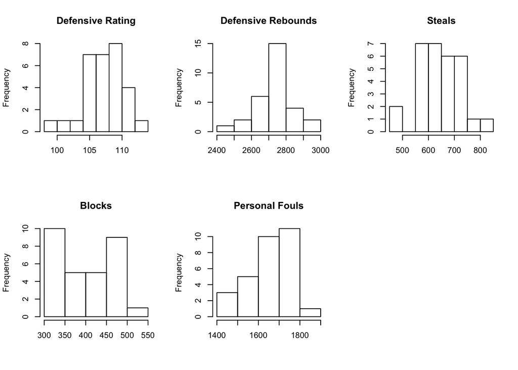

```r
par(mfrow=c(2,3))
hist(df$DRtg, main="Defensive Rating", xlab="")
hist(df$DRB, main="Defensive Rebounds", xlab="")
hist(df$STL, main="Steals", xlab="")
hist(df$BLK, main="Blocks", xlab="")
hist(df$PF, main="Personal Fouls", xlab="")
```

These histograms are mostly normal. However: the Defensive Rating seems to have a left tail, Blocks isn’t quite normal, and Personal Fouls takes a strange turn if you go past 1800. But none of these look to bad so we can leave ’em.

We can make scatterplots of each variable versus defensive rating.

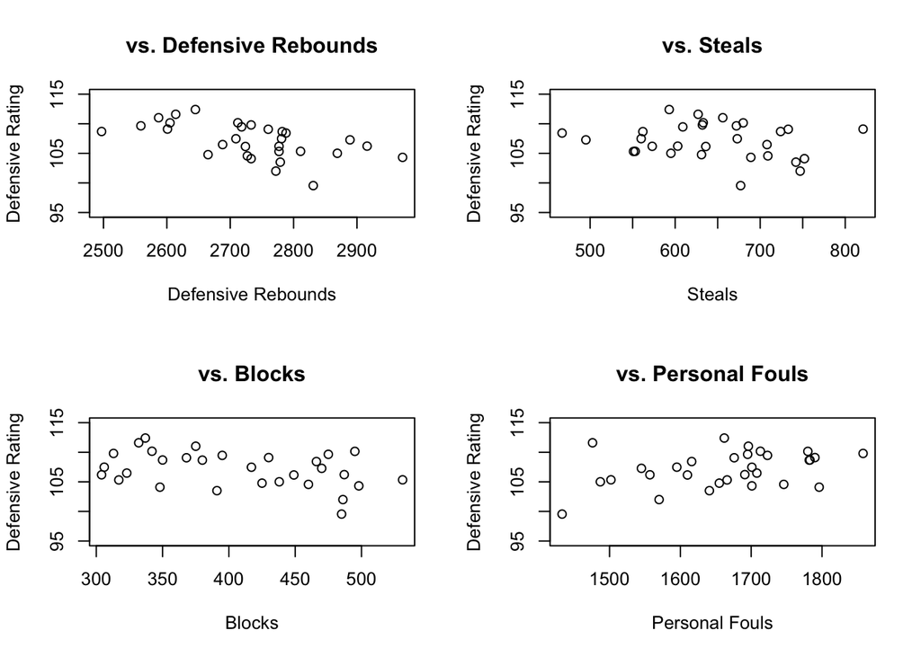

```r
par(mfrow=c(2,2))
plot(df$DRB, df$DRtg, main="vs. Defensive Rebounds", xlab="Defensive Rebounds", ylab="Defensive Rating", ylim=c(95,115))
plot(df$STL, df$DRtg, main="vs. Steals", xlab="Steals", ylab="Defensive Rating", ylim=c(95,115))
plot(df$BLK, df$DRtg, main="vs. Blocks", xlab="Blocks", ylab="Defensive Rating", ylim=c(95,115))
plot(df$PF, df$DRtg, main="vs. Personal Fouls", xlab="Personal Fouls", ylab="Defensive Rating", ylim=c(95,115))
```

There appears to be a relationship in all of the plots, to differing degress. Defensive Rebounds appear to have the strongest correlation, followed by Steals and Personal Fouls. The relationships with Blocks is unclear.

In terms of outliers and leverage points, there look to be a few. For Defensive Rebounds, there seems to be a leverage point on the left side of the plot, which corresponds to the Memphis Grizzlies. Steals seems to have a leverage point all the way on the right of the plot, which represents the Houston Rockets. Finally, the Personal Foul plot has an outlier at the bottom left, the San Antonio Spurs.

Let’s run a regression and see the results.

```r
reg1 <- lm(data=df, DRtg ~ DRB + STL + BLK + PF)
summary(reg1)
```

```
##
## Call:
## lm(formula = DRtg ~ DRB + STL + BLK + PF, data = df)
##
## Residuals:
##     Min      1Q  Median      3Q     Max
## -3.5789 -1.0478 -0.0292  1.2469  3.7755
##
## Coefficients:
##               Estimate Std. Error t value Pr(>|t|)
## (Intercept) 150.783031  14.830308  10.167 2.29e-10 ***
## DRB          -0.016407   0.004133  -3.970 0.000536 ***
## STL          -0.019138   0.005377  -3.559 0.001520 **
## BLK          -0.004433   0.005965  -0.743 0.464307
## PF            0.009221   0.004121   2.237 0.034408 *
## ---
## Signif. codes:  0 '***' 0.001 '**' 0.01 '*' 0.05 '.' 0.1 ' ' 1
##
## Residual standard error: 2.045 on 25 degrees of freedom
## Multiple R-squared:  0.5896, Adjusted R-squared:  0.5239
## F-statistic: 8.977 on 4 and 25 DF,  p-value: 0.0001226
```

Ok! The R^2 (adjusted) is 52%, which is pretty good. The Residual Standard Error is 2.045, which means that we can predict the Defensive Rating to within 4.09 points per 100 posessions.

The F statistic is significant at 8.977, with a P-Value of .0001.

To determine if we have an issue with collinearity, we can use VIF.

```r
library(car)
vif(reg1)
```

```
##      DRB      STL      BLK       PF
## 1.373009 1.313552 1.179852 1.315145
```

To evaluate whether these numbers pose an issue to our regression, we use the formula MAX(10, 1/(1-R^2)). In our case, 1/(1-R^2) evaluates to 2.1. The VIF (Variance Inflation Factors) all hover between 1 and 2, which means that multicollinearity isn’t an issue in our regression.

The Y-intercept of 150 isn’t particularly meaningful, as it describes a team without any Defensive Rebounds, Steals, Blocks, and Personal Fouls (a bad defense indeed).

Analyzing the coefficients:

1. Defensive Rebounds: the coefficient is -.0164, meaning that every defensive rebound that a team pulls in is associated with .0164 less points allowed per 100 possessions, holding all other variables fixed. In other words, every additional 60 rebounds is associated with one point less allowed per 100 possessions.
2. Steals: the coefficient is -.0191, meaning that every team steal is associated with .0191 less points allowed per 100 possessions, holding all other variables fixed. This means that every 53 steals are associated with one point less allowed per 100 possessions.
3. Blocks: the coefficient is -.0044, meaning that every team block is associated with .0044 less points allowed per 100 possessions, holding all other variables fixed. This means that every 227 blocks are associated with one point less allowed per 100 possessions.
4. Personal Fouls: the coefficient is .0092, meaning that every personal foul is associated with .0092 more points allowed per 100 possessions, holding all other variables fixed (a positive correlation, unlike the other 3 variables). This means that every 109 personal fouls are associated with one more point allowed per 100 possessions.

Residual plots:

First, standardize the residuals.

```r
res.stand <- rstandard(reg1)
```

Then plot them.

```
## numeric(0)
```

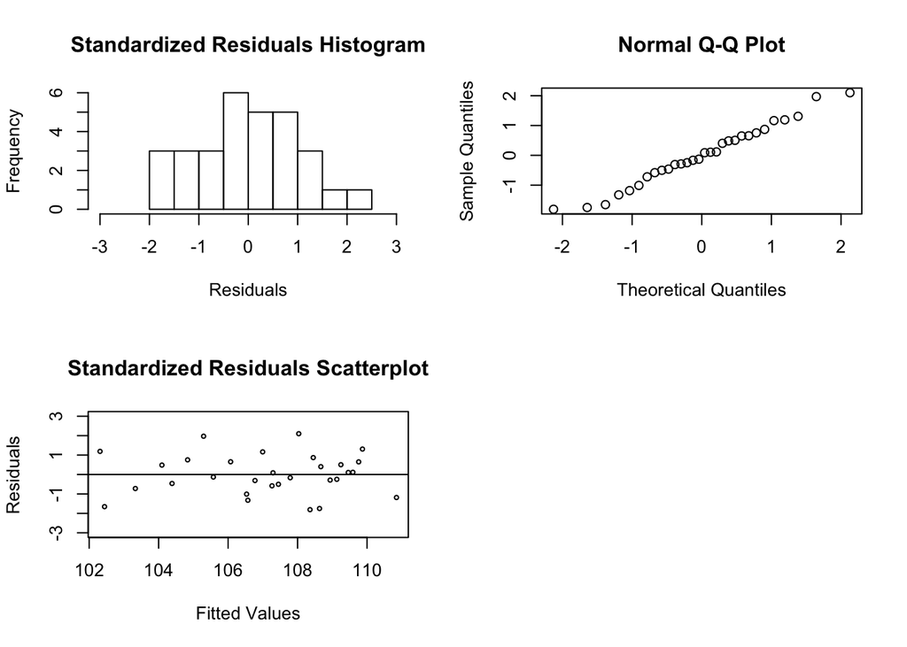

```r
par(mfrow=c(2,2))
hist(res.stand, main="Standardized Residuals Histogram", xlab="Residuals", xlim=c(-3,3))
qqnorm(res.stand)
plot(reg1$fitted.values, res.stand, main="Standardized Residuals Scatterplot", xlab="Fitted Values", ylab="Residuals", cex=.5, ylim=c(-3,3))  + abline(a=0, b=0)
```

```r
par(mfrow=c(2,2))

plot(df$DRB, res.stand, main="Standardized Residuals vs. Defensive Rebounds", xlab="Defensive Rebounds", ylab="Residuals", cex=.5, ylim=c(-3,3)) + abline(a=0,b=0)
```

```
## numeric(0)
```

```r
plot(df$STL, res.stand, main="Standardized Residuals vs. Steals", xlab="Steals", ylab="Residuals", cex=.5, ylim=c(-3,3)) + abline(a=0,b=0)
```

```
## numeric(0)
```

```r
plot(df$BLK, res.stand, main="Standardized Residuals vs. Blocks", xlab="Blocks", ylab="Residuals", cex=.5, ylim=c(-3,3)) + abline(a=0,b=0)
```

```
## numeric(0)
```

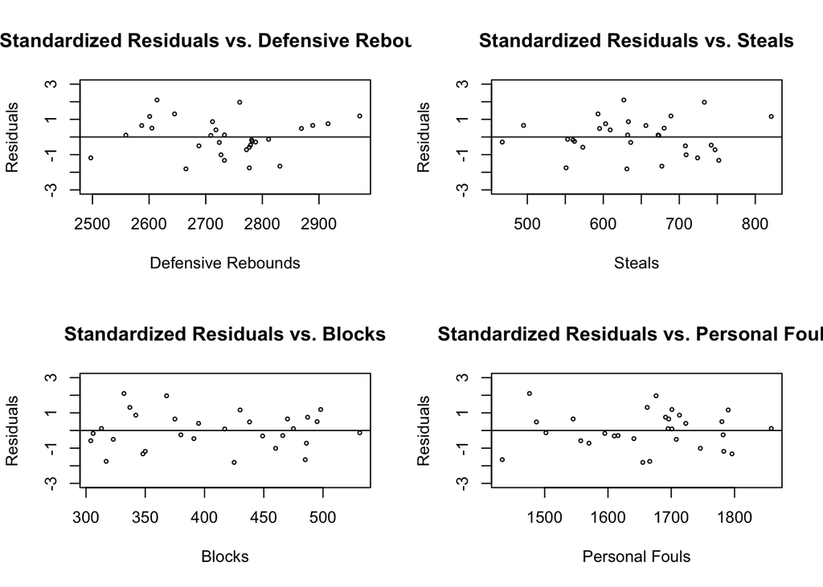

```
## numeric(0)
```

```r
plot(df$PF, res.stand, main="Standardized Residuals vs. Personal Fouls", xlab="Personal Fouls", ylab="Residuals", cex=.5, ylim=c(-3,3)) + abline(a=0,b=0)
```

The plots of residuals vs. each of the individual predictors don’t show any significant pattern either. As noted above, on the steals graph, there appears to be a leverage point all the way to the right, corresponding to the Houston Rockets, with a league leading 821 steals (70 more than the second best Boston Celtics). Another issue to look out for is possible left leverage points in Defensive Rebounds (Memphis Grizzlies) and in Personal Fouls (San Antonio Spurs).

To take a look at the regression diagnostics, we’ll create a dataframe with the team name, standardized residuals, leverage values, and Cook’s distances.

```r
teams <- df$Team
leverage_values <- hatvalues(reg1)
cooks_distances <- cooks.distance(reg1)
diagnostics <- data.frame(teams, res.stand, leverage_values, cooks_distances)

#Define the max leverage value: 2.5 * (number of predicting variables + 1 / n) = .4166

arranged <- arrange(diagnostics, desc(leverage_values))
arranged
```

```
##                     teams   res.stand leverage_values cooks_distances
## 1   Golden State Warriors  1.19150338      0.32110131    1.342943e-01
## 2           Brooklyn Nets  2.10069542      0.31082208    3.980491e-01
## 3       San Antonio Spurs -1.65422320      0.26903308    2.014309e-01
## 4         New York Knicks -0.28744851      0.25276619    5.590010e-03
## 5      Philadelphia 76ers  0.50369348      0.23272297    1.539039e-02
## 6            Phoenix Suns  0.11545598      0.22693062    7.825957e-04
## 7         Milwaukee Bucks  0.10493675      0.22032737    6.223596e-04
## 8         Houston Rockets  1.16534981      0.21993241    7.657722e-02
## 9              Miami Heat -0.13012112      0.21630263    9.346285e-04
## 10      Memphis Grizzlies -1.18390233      0.20525805    7.239954e-02
## 11  Oklahoma City Thunder  0.75407414      0.19171256    2.697384e-02
## 12          Chicago Bulls  0.65607149      0.19017202    2.021558e-02
## 13          Atlanta Hawks -0.72103855      0.18730480    2.396449e-02
## 14        Detroit Pistons -0.58174604      0.18469386    1.533305e-02
```

[output cut: 16 more lines]

Now we’ll work on choosing the best model.

Using Mallows CP:

```r
cp <- leaps(cbind(df$STL, df$BLK, df$PF, df$DRB), names=c("steals","blocks","fouls","d rebounds"), df$DRtg, method= "Cp", nbest=2)
cp_values <- cp$Cp
cp
```

```
## $which
##   steals blocks fouls d rebounds
## 1  FALSE  FALSE FALSE       TRUE
## 1  FALSE   TRUE FALSE      FALSE
## 2   TRUE  FALSE FALSE       TRUE
## 2  FALSE   TRUE FALSE       TRUE
## 3   TRUE  FALSE  TRUE       TRUE
## 3   TRUE   TRUE FALSE       TRUE
## 4   TRUE   TRUE  TRUE       TRUE
##
## $label
## [1] "(Intercept)" "steals"      "blocks"      "fouls"       "d rebounds"
##
## $size
## [1] 2 2 3 3 4 4 5
##
## $Cp
## [1] 15.904567 26.136332  7.434006 15.095417  3.552299  8.006264  5.000000
```

Since P is 4, it would appear that the best model is the one with all variables except blocks - it has a Mallows CP value of 3.5, which is close to p. We’ll put these values into a diagnostic dataframe and add in a few other measures of best subset.

```r
diag_df <- data.frame("Combinations" = c("DRB","BLK","STL,DRB","BLK,DRB","STL,PF,DRB","STL,BLK,DRB","STL,BLK,DRB,PF"))
diag_df2 <- data.frame("Combinations" = c("DRB","BLK","STL,DRB","BLK,DRB","STL,PF,DRB","STL,BLK,DRB","STL,BLK,DRB,PF"))
```

We can also try the adjusted R2 method.

```r
r2adj <- leaps(cbind(df$STL, df$BLK, df$PF, df$DRB), names=c("steals","blocks","fouls","d rebounds"), df$DRtg, method= "adjr2", nbest=2)
r2adj_values <- r2adj$adjr2
```

And we’ll do the same with the regular R^2.

```r
r2 <- leaps(cbind(df$STL, df$BLK, df$PF, df$DRB), names=c("steals","blocks","fouls","d rebounds"), df$DRtg, method= "r2", nbest=2)
r2_values <- r2$r2
```

Another set of diagnostics we can use are AIC and AICc.

Model combinations copied from the Mallows CP test (leaps) above.

```r
AIC_values <- c(extractAIC(lm(data=df, DRtg ~ DRB))[2],
extractAIC(lm(data=df, DRtg ~ BLK))[2],
extractAIC(lm(data=df, DRtg ~ STL + DRB))[2],
extractAIC(lm(data=df, DRtg ~ BLK + DRB))[2],
extractAIC(lm(data=df, DRtg ~ STL + PF + DRB))[2],
extractAIC(lm(data=df, DRtg ~ STL + BLK + DRB))[2],
extractAIC(lm(data=df, DRtg ~ STL + BLK + DRB + PF))[2])
```

Now we’ll do the same for AICc.

```r
AICc_values <- c(AICc(lm(data=df, DRtg ~ DRB)),
AICc(lm(data=df, DRtg ~ BLK)),
AICc(lm(data=df, DRtg ~ STL + DRB)),
AICc(lm(data=df, DRtg ~ BLK + DRB)),
AICc(lm(data=df, DRtg ~ STL + PF + DRB)),
AICc(lm(data=df, DRtg ~ STL + BLK + DRB)),
AICc(lm(data=df, DRtg ~ STL + BLK + DRB + PF)))
```

We’ll add the values into the diagnostic dataframe, and take a look at them.

```r
diag_df$R2 <- r2_values
diag_df$R2Adj <- r2adj_values

diag_df2$MCP <- cp_values
diag_df2$AIC <- AIC_values
diag_df2$AICc <- AICc_values
```

```r
diag_df
```

```
##     Combinations        R2     R2Adj
## 1            DRB 0.3120246 0.2874540
## 2            BLK 0.1440428 0.1134729
## 3        STL,DRB 0.4839268 0.4456992
## 4        BLK,DRB 0.3581443 0.3105994
## 5     STL,PF,DRB 0.5804908 0.5320858
## 6    STL,BLK,DRB 0.5073670 0.4505248
## 7 STL,BLK,DRB,PF 0.5895582 0.5238875
```

```r
diag_df2
```

```
##     Combinations       MCP      AIC     AICc
## 1            DRB 15.904567 56.94463 145.0040
## 2            BLK 26.136332 63.49865 151.5580
## 3        STL,DRB  7.434006 50.31950 139.0558
## 4        BLK,DRB 15.095417 56.86295 145.5993
## 5     STL,PF,DRB  3.552299 46.10461 135.7409
## 6    STL,BLK,DRB  8.006264 50.92497 140.5613
## 7 STL,BLK,DRB,PF  5.000000 47.44906 138.2375
```

We’ll try removing Blocks from the regression and see if it has an impact.

```r
reg2 <- lm(data=df, DRtg ~ STL + PF + DRB)
summary(reg2)
```

```
##
## Call:
## lm(formula = DRtg ~ STL + PF + DRB, data = df)
##
## Residuals:
##     Min      1Q  Median      3Q     Max
## -3.7296 -0.8261 -0.0802  1.1113  4.0334
##
## Coefficients:
##               Estimate Std. Error t value Pr(>|t|)
## (Intercept) 150.993683  14.699385  10.272 1.21e-10 ***
## STL          -0.019946   0.005220  -3.821 0.000744 ***
## PF            0.009809   0.004009   2.446 0.021504 *
## DRB          -0.017310   0.003916  -4.420 0.000155 ***
## ---
## Signif. codes:  0 '***' 0.001 '**' 0.01 '*' 0.05 '.' 0.1 ' ' 1
##
## Residual standard error: 2.027 on 26 degrees of freedom
## Multiple R-squared:  0.5805, Adjusted R-squared:  0.5321
## F-statistic: 11.99 on 3 and 26 DF,  p-value: 4.074e-05
```

VIFs look good too.

```r
vif(reg2)
```

```
##      STL       PF      DRB
## 1.259816 1.266686 1.254287
```

Like before, we’ll plot the standardized residuals in a 4(3 in our case) in 1 plot and then versus each of the individual predictors.

```r
res.stand2 <- rstandard(reg2)
```

```
## numeric(0)
```

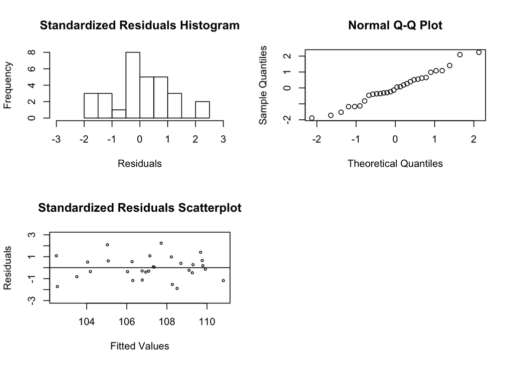

```r
par(mfrow=c(2,2))
hist(res.stand2, main="Standardized Residuals Histogram", xlab="Residuals", xlim=c(-3,3))
qqnorm(res.stand2)
plot(reg2$fitted.values, res.stand2, main="Standardized Residuals Scatterplot", xlab="Fitted Values", ylab="Residuals", cex=.5, ylim=c(-3,3))  + abline(a=0, b=0)
```

```r
par(mfrow=c(2,2))

plot(df$DRB, res.stand2, main="Standardized Residuals vs. Defensive Rebounds", xlab="Defensive Rebounds", ylab="Residuals", cex=.5, ylim=c(-3,3)) + abline(a=0,b=0)
```

```
## numeric(0)
```

```r
plot(df$STL, res.stand2, main="Standardized Residuals vs. Steals", xlab="Steals", ylab="Residuals", cex=.5, ylim=c(-3,3)) + abline(a=0,b=0)
```

```
## numeric(0)
```

```
## numeric(0)
```

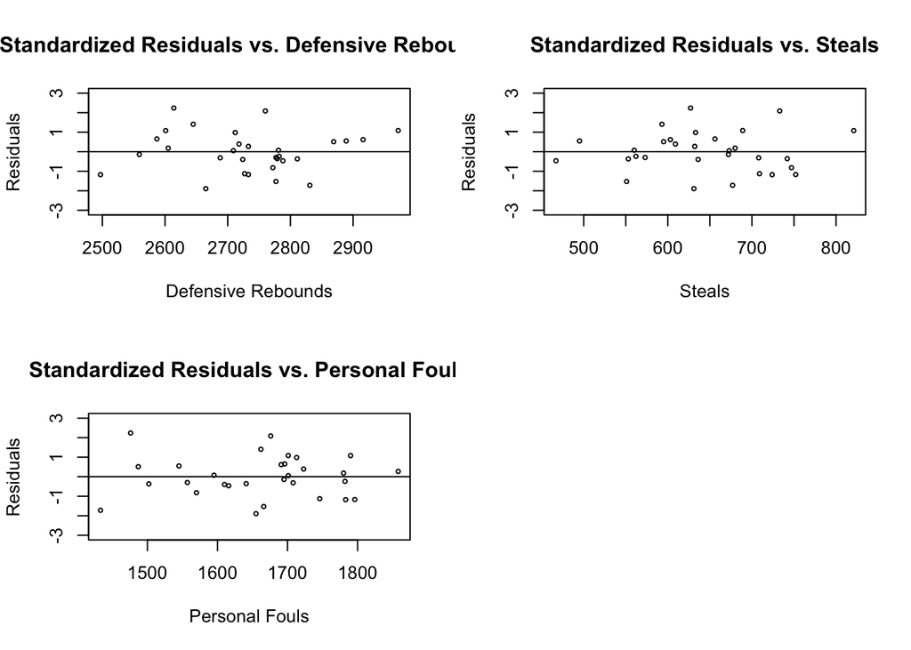

```r
plot(df$PF, res.stand2, main="Standardized Residuals vs. Personal Fouls", xlab="Personal Fouls", ylab="Residuals", cex=.5, ylim=c(-3,3)) + abline(a=0,b=0)
```

```r
df2 <- df[which(df$Team != "Brooklyn Nets"),]
reg3 <- lm(data=df2, DRtg ~ STL + PF + DRB)
summary(reg3)
```

```
##
## Call:
## lm(formula = DRtg ~ STL + PF + DRB, data = df2)
##
## Residuals:
##     Min      1Q  Median      3Q     Max
## -3.2799 -0.9565 -0.0893  0.9965  4.0559
##
## Coefficients:
##               Estimate Std. Error t value Pr(>|t|)
## (Intercept) 133.884919  15.182390   8.818  3.8e-09 ***
## STL          -0.019943   0.004783  -4.169  0.00032 ***
## PF            0.014203   0.004091   3.472  0.00189 **
## DRB          -0.013789   0.003867  -3.565  0.00150 **
## ---
## Signif. codes:  0 '***' 0.001 '**' 0.01 '*' 0.05 '.' 0.1 ' ' 1
##
## Residual standard error: 1.858 on 25 degrees of freedom
## Multiple R-squared:  0.6314, Adjusted R-squared:  0.5872
## F-statistic: 14.28 on 3 and 25 DF,  p-value: 1.272e-05
```

Final diagnostics:

```r
teams <- df$Team
leverage_values <- hatvalues(reg2)
cooks_distances <- cooks.distance(reg2)
diagnostics <- data.frame(teams, res.stand, leverage_values, cooks_distances)

#Define the max leverage value: 2.5 * (number of predicting variables + 1 / n) = .4166

arranged <- arrange(diagnostics, desc(res.stand))
```

[output not shown]